# ESS-Lab-4

Author

Aldair Perez

# Part 1

```r
remotes::install_github("lter/lterdatasampler", force = TRUE)
```

```r
library(tidyverse)
library(ggpubr)
library(lterdatasampler)
library(car)
library(visdat)
library(dplyr)
```

```r
view(and_vertebrates)
```

## Question 1.)

```r
coastal_giant_salamander_data <- and_vertebrates %>%
  filter(species == "Coastal giant salamander")
```

```r
contingency_table <- table(coastal_giant_salamander_data$section, coastal_giant_salamander_data$unittype)
```

```r
print(contingency_table)
```

```
        C   IP    P    R    S   SC
  CC 3757    0  711    0    2  936
  OG 3940   50 1232   72    0 1058
```

```r
chi_square_result <- chisq.test(contingency_table)
print(chi_square_result)
```

```
    Pearson's Chi-squared test

data:  contingency_table
X-squared = 200.71, df = 5, p-value < 2.2e-16
```

The p-value from this chi test is (p-value < 2.2e-16).

## Question 2.)

```r
unique(coastal_giant_salamander_data$section)
```

```
[1] "CC" "OG"
```

```r
clear_cut_data <- coastal_giant_salamander_data[coastal_giant_salamander_data$section == "CC", ]
old_growth_data <- coastal_giant_salamander_data[coastal_giant_salamander_data$section == "OG", ]
```

```r
t_test_result <- t.test(weight_g ~ section, data = coastal_giant_salamander_data[coastal_giant_salamander_data$section %in% c("CC", "OG"), ])
print(t_test_result)
```

```
    Welch Two Sample t-test

data:  weight_g by section
t = 4.9255, df = 6335.9, p-value = 8.629e-07
alternative hypothesis: true difference in means between group CC and group OG is not equal to 0
95 percent confidence interval:
 0.8978633 2.0850725
sample estimates:
mean in group CC mean in group OG
        9.810634         8.319166
```

The p-value is (8.629e-07). This means the difference in species biomass for CC and OG is statistically significant since the p-value is less than 0.05.

## Question 3.)

```r
cutthroat_trout_data <- and_vertebrates[and_vertebrates$species == "Cutthroat trout", ]
```

```r
cor_test_result <- cor.test(cutthroat_trout_data$length_1_mm, cutthroat_trout_data$weight_g)
print(cor_test_result)
```

```
    Pearson's product-moment correlation

data:  cutthroat_trout_data$length_1_mm and cutthroat_trout_data$weight_g
t = 249.5, df = 12590, p-value < 2.2e-16
alternative hypothesis: true correlation is not equal to 0
95 percent confidence interval:
 0.9090311 0.9149092
sample estimates:
     cor
0.912017
```

The cor for the correlation for length and weight for the trout is 0.912017, which means there’s a strong correlation for length and weight.

# Part 2

```r
install.packages("car")
library(car)
??car
```

```
starting httpd help server ... done
```

```r
data("pie_crab")
?pie_crab
count(pie_crab, site)
```

```
# A tibble: 13 × 2
   site      n
   <chr> <int>
 1 BC       37
 2 CC       27
 3 CT       33
 4 DB       30
 5 GTM      28
 6 JC       30
 7 NB       29
 8 NIB      30
 9 PIE      28
10 RC       25
11 SI       30
12 VCR      30
13 ZI       35
```

```r
summary(pie_crab)
```

```
      date               latitude         site                size
 Min.   :2016-07-24   Min.   :30.00   Length:392         Min.   : 6.64
 1st Qu.:2016-07-28   1st Qu.:34.00   Class :character   1st Qu.:12.02
 Median :2016-08-01   Median :39.10   Mode  :character   Median :14.44
 Mean   :2016-08-02   Mean   :37.69                      Mean   :14.66
 3rd Qu.:2016-08-09   3rd Qu.:41.60                      3rd Qu.:17.34
 Max.   :2016-08-13   Max.   :42.70                      Max.   :23.43
    air_temp      air_temp_sd      water_temp    water_temp_sd
 Min.   :10.29   Min.   :6.391   Min.   :13.98   Min.   :4.838
 1st Qu.:12.05   1st Qu.:8.110   1st Qu.:14.33   1st Qu.:6.567
 Median :13.93   Median :8.410   Median :17.50   Median :6.998
 Mean   :15.20   Mean   :8.654   Mean   :17.65   Mean   :7.252
 3rd Qu.:18.63   3rd Qu.:9.483   3rd Qu.:20.54   3rd Qu.:7.865
 Max.   :21.79   Max.   :9.965   Max.   :24.50   Max.   :9.121
     name
 Length:392
 Class :character
 Mode  :character
```

```r
pie_sites <- pie_crab |>
  filter(site %in% c("GTM", "DB", "PIE"))
leveneTest(size ~ site, data = pie_sites)
```

```
Levene's Test for Homogeneity of Variance (center = median)
      Df F value Pr(>F)
group  2   0.548 0.5802
      83
```

## Question 1.)

```r
pie_sites <- pie_sites %>%
  arrange(latitude) %>%
  mutate(site = factor(site, levels = unique(site)))
```

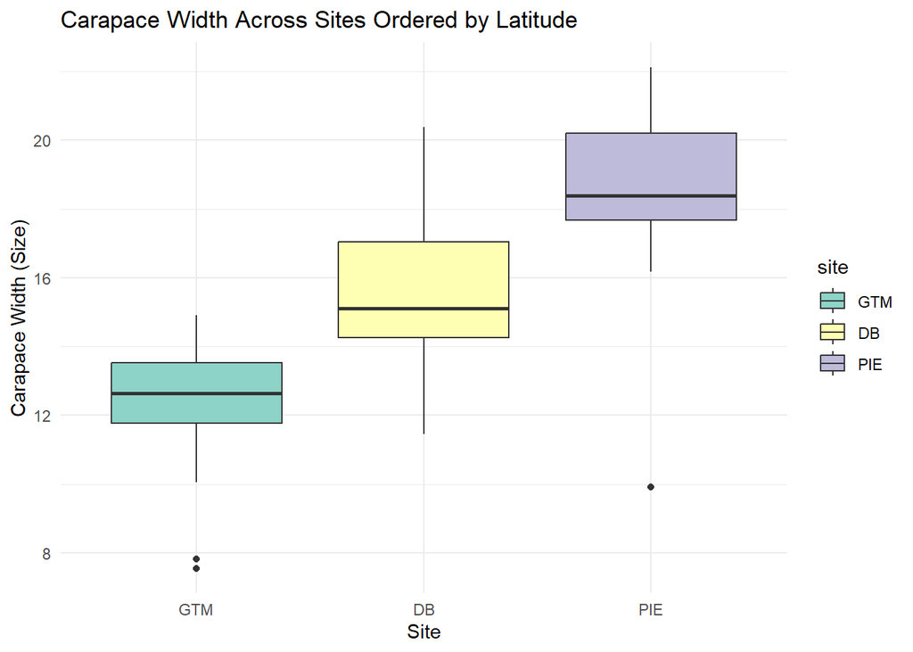

```r
ggplot(pie_sites, aes(x = site, y = size, fill = site)) +
  geom_boxplot() +
  theme_minimal() +
  labs(title = "Carapace Width Across Sites Ordered by Latitude",
       x = "Site", y = "Carapace Width (Size)") +
  scale_fill_brewer(palette = "Set3")
```

```r
anova_result <- aov(size ~ site, data = pie_sites)
summary(anova_result)
```

```
            Df Sum Sq Mean Sq F value Pr(>F)
site         2  521.5  260.75   60.02 <2e-16 ***
Residuals   83  360.6    4.34
---
Signif. codes:  0 '***' 0.001 '**' 0.01 '*' 0.05 '.' 0.1 ' ' 1
```

According to the box plot and ANOVA test, the PIE site generally has a larger width site, followed by sites DB then GTM.

## Question 2.)

```r
model_water <- lm(size ~ water_temp_sd, data = pie_sites)
summary(model_water)
```

```
Call:
lm(formula = size ~ water_temp_sd, data = pie_sites)

Residuals:
    Min      1Q  Median      3Q     Max
-8.1765 -2.2390  0.0938  2.3616  5.9538

Coefficients:
              Estimate Std. Error t value Pr(>|t|)
(Intercept)    17.8720     1.3216  13.523   <2e-16 ***
water_temp_sd  -0.3505     0.1891  -1.854   0.0673 .
---
Signif. codes:  0 '***' 0.001 '**' 0.01 '*' 0.05 '.' 0.1 ' ' 1

Residual standard error: 3.176 on 84 degrees of freedom
Multiple R-squared:  0.03929,   Adjusted R-squared:  0.02786
F-statistic: 3.436 on 1 and 84 DF,  p-value: 0.06731
```

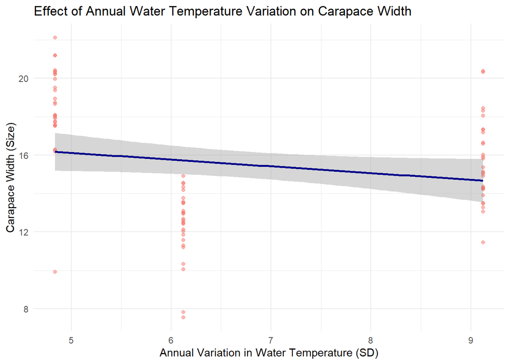

```r
ggplot(pie_sites, aes(x = water_temp_sd, y = size)) +
  geom_point(aes(color = "darkorange"), alpha = 0.5) +
  geom_smooth(method = "lm", color = "darkblue", se = TRUE) +
  labs(title = "Effect of Annual Water Temperature Variation on Carapace Width",
       x = "Annual Variation in Water Temperature (SD)",
       y = "Carapace Width (Size)") +
  theme_minimal() +
  theme(legend.position = "none")
```

According to the plot graph and lm, the data plots are almost away from the line of best fit, so the result is water_temp_sd and width size have no relationship.

## Question 3.)

```r
correlation_matrix <- cor(pie_sites[, c("latitude", "air_temp_sd", "water_temp_sd")], use = "complete.obs")
print(correlation_matrix)
```

```
                 latitude air_temp_sd water_temp_sd
latitude       1.00000000   0.9139478   -0.03944242
air_temp_sd    0.91394775   1.0000000    0.36946777
water_temp_sd -0.03944242   0.3694678    1.00000000
```

```r
model_multiple <- lm(size ~ latitude + air_temp_sd + water_temp_sd, data = pie_sites)
summary(model_multiple)
```

```
Call:
lm(formula = size ~ latitude + air_temp_sd + water_temp_sd, data = pie_sites)

Residuals:
    Min      1Q  Median      3Q     Max
-8.5839 -1.0809  0.0818  1.4313  4.7760

Coefficients: (1 not defined because of singularities)
              Estimate Std. Error t value Pr(>|t|)
(Intercept)    -2.7151     1.6867  -1.610   0.1113
latitude        0.6844     0.1047   6.536 4.82e-09 ***
air_temp_sd    -0.8470     0.3522  -2.405   0.0184 *
water_temp_sd       NA         NA      NA       NA
---
Signif. codes:  0 '***' 0.001 '**' 0.01 '*' 0.05 '.' 0.1 ' ' 1

Residual standard error: 2.084 on 83 degrees of freedom
Multiple R-squared:  0.5912,    Adjusted R-squared:  0.5814
F-statistic: 60.02 on 2 and 83 DF,  p-value: < 2.2e-16
```